# FinalProject2

## In this project I chose to try my best at detecting pneumonia in chest X-RAY images.

## The main method involves using transfer learning from various different kernels already trained on 'imagenet', while trying to keep their bottom layers that have very general and broad features static and train the top level layers.

## In the end we take all of these models and ensemble them into one prediction model in hope to get the most accurate result.

```python
from keras import backend as K
from keras.models import Sequential
from keras.layers.core import Flatten, Dense, Dropout, Activation
from keras.layers.convolutional import Conv2D, MaxPooling2D, ZeroPadding2D
from matplotlib import pyplot as plt
import cv2
import numpy as np
import os
#from sklearn.model_selection import train_test_split
from PIL import Image
from keras.preprocessing.image import ImageDataGenerator, load_img
from keras.models import load_model
from keras.optimizers import Adam

import random
#from utils import Aug
```

```python
mainDIR = os.listdir('C:/Computer Vision Project/chest_xray/')
print(mainDIR)
```

```
['test', 'train', 'val']
```

```python
train_folder = 'C:/Computer Vision Project/chest_xray/train/'
val_folder = 'C:/Computer Vision Project/chest_xray/val/'
test_folder = 'C:/Computer Vision Project/chest_xray/test/'
```

```python
# train
os.listdir(train_folder)
train_n = train_folder+'NORMAL/'
train_p = train_folder+'PNEUMONIA/'
```

```
1341
normal picture title:  NORMAL2-IM-1240-0001.jpeg
pneumonia picture title: person1562_bacteria_4078.jpeg
```

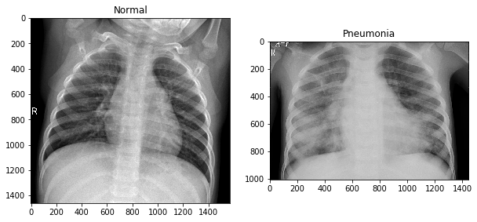

```python
#Normal pic
print(len(os.listdir(train_n)))
rand_norm= np.random.randint(0,len(os.listdir(train_n)))
norm_pic = os.listdir(train_n)[rand_norm]
print('normal picture title: ',norm_pic)

norm_pic_address = train_n+norm_pic

#Pneumonia
rand_p = np.random.randint(0,len(os.listdir(train_p)))

sic_pic =  os.listdir(train_p)[rand_norm]
sic_address = train_p+sic_pic
print('pneumonia picture title:', sic_pic)

# Load the images
norm_load = Image.open(norm_pic_address)
sic_load = Image.open(sic_address)

#Let's plt these images
f = plt.figure(figsize= (10,6))
a1 = f.add_subplot(1,2,1)
img_plot = plt.imshow(norm_load)
a1.set_title('Normal')

a2 = f.add_subplot(1, 2, 2)
img_plot = plt.imshow(sic_load)
a2.set_title('Pneumonia')
```

```python
# Same shape given as imagenet images
input_shape = (224,224)
batch_size = 16
```

```python
from keras_preprocessing.image_dev import ImageDataGenerator as myImageDataGenerator
```

## Fitting the CNN to the images

#### I modified 'ImageDataGenerator' to include 'keep_aspect_ratio' in order to keep the images in their original ratios padded by black bars. Chose not to use flip or mirror as the organs' position does matter and I believe that a real world x-ray would not be flipped.

```python
train_datagen = myImageDataGenerator(rescale = 1./255,
                                   shear_range = 0.05,
                                   zoom_range = 0.1,
                                   rotation_range=10,
                                   width_shift_range=0.05,
                                   height_shift_range=0.05,
                                   fill_mode='constant',
                                   cval=0)

test_datagen = myImageDataGenerator(rescale = 1./255)  #Image normalization.

training_set = train_datagen.flow_from_directory(train_folder,
                                                 target_size = input_shape,
                                                 batch_size = batch_size,
                                                 class_mode = 'binary',
                                                 keep_aspect_ratio=True)

validation_set = test_datagen.flow_from_directory(val_folder,
                                                  target_size=input_shape,
                                                  batch_size=batch_size,
                                                  class_mode='binary',
                                                  keep_aspect_ratio=True)

test_set = test_datagen.flow_from_directory(test_folder,
                                            target_size = input_shape,
                                            batch_size = batch_size,
                                            class_mode = 'binary')
```

```
Found 5216 images belonging to 2 classes.
Found 16 images belonging to 2 classes.
Found 624 images belonging to 2 classes.
```

from keras.optimizers import Adam optim = Adam()

```python
# test
os.listdir(test_folder)
test_n = test_folder+'NORMAL/'
test_p = test_folder+'PNEUMONIA/'
```

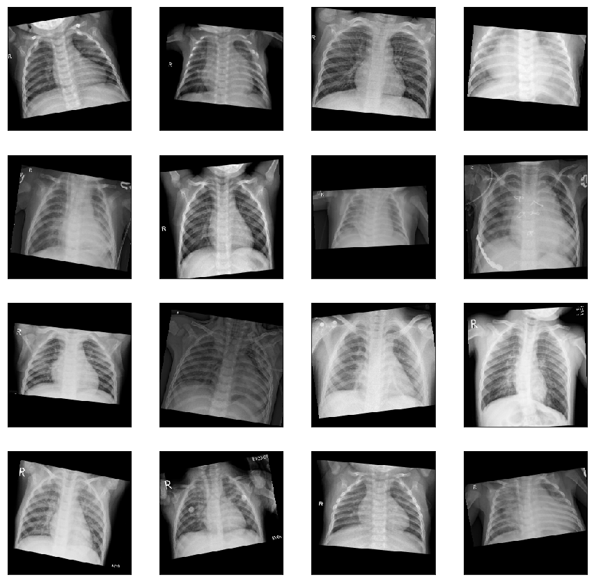

```python
x,y = next(training_set)
plt.figure(figsize=[15,15])
for index in range(16):
    plt.subplot(4,4,index+1)
    plt.imshow(x[index,...,0], cmap='gray')
    plt.tick_params(axis='both', which='both', bottom=False, left=False, labelbottom=False, labelleft=False)
```

# VGG16

#### For VGG16 we lock the bottom block of convolutional layers to maintain the broad and very general features from imagenet intact. Afterwards we train once more only on our added top fully connected layers to try and fine tune them.

```python
from keras.applications import vgg16
```

```python
conv_base_vgg16 = vgg16.VGG16(include_top=False,
                        weights="imagenet",
                        input_shape=training_set.image_shape)
```

```python
conv_base_vgg16.summary()
```

```
_________________________________________________________________
Layer (type)                 Output Shape              Param #
=================================================================
input_1 (InputLayer)         (None, 224, 224, 3)       0
_________________________________________________________________
block1_conv1 (Conv2D)        (None, 224, 224, 64)      1792
_________________________________________________________________
block1_conv2 (Conv2D)        (None, 224, 224, 64)      36928
_________________________________________________________________
block1_pool (MaxPooling2D)   (None, 112, 112, 64)      0
_________________________________________________________________
block2_conv1 (Conv2D)        (None, 112, 112, 128)     73856
_________________________________________________________________
block2_conv2 (Conv2D)        (None, 112, 112, 128)     147584
_________________________________________________________________
block2_pool (MaxPooling2D)   (None, 56, 56, 128)       0
_________________________________________________________________
block3_conv1 (Conv2D)        (None, 56, 56, 256)       295168
_________________________________________________________________
block3_conv2 (Conv2D)        (None, 56, 56, 256)       590080
_________________________________________________________________
block3_conv3 (Conv2D)        (None, 56, 56, 256)       590080
_________________________________________________________________
block3_pool (MaxPooling2D)   (None, 28, 28, 256)       0
_________________________________________________________________
block4_conv1 (Conv2D)        (None, 28, 28, 512)       1180160
_________________________________________________________________
block4_conv2 (Conv2D)        (None, 28, 28, 512)       2359808
_________________________________________________________________
block4_conv3 (Conv2D)        (None, 28, 28, 512)       2359808
_________________________________________________________________
block4_pool (MaxPooling2D)   (None, 14, 14, 512)       0
_________________________________________________________________
block5_conv1 (Conv2D)        (None, 14, 14, 512)       2359808
_________________________________________________________________
block5_conv2 (Conv2D)        (None, 14, 14, 512)       2359808
_________________________________________________________________
block5_conv3 (Conv2D)        (None, 14, 14, 512)       2359808
_________________________________________________________________
block5_pool (MaxPooling2D)   (None, 7, 7, 512)         0
=================================================================
Total params: 14,714,688
Trainable params: 14,714,688
Non-trainable params: 0
_________________________________________________________________
```

```python
model_vgg16 = Sequential()
model_vgg16.add(conv_base_vgg16)
# Flatten the layer
model_vgg16.add(Flatten())

model_vgg16.add(Dense(units = 1024))
model_vgg16.add(Dropout(0.3))
model_vgg16.add(Activation('relu'))
model_vgg16.add(Dense(units = 256))
model_vgg16.add(Dropout(0.3))
model_vgg16.add(Activation('relu'))
model_vgg16.add(Dense(units = 32))

# Fully Connected Layers
model_vgg16.add(Dense(activation = 'sigmoid', units = 1))
```

```python
model_vgg16.summary()
```

```
_________________________________________________________________
Layer (type)                 Output Shape              Param #
=================================================================
vgg16 (Model)                (None, 7, 7, 512)         14714688
_________________________________________________________________
flatten_1 (Flatten)          (None, 25088)             0
_________________________________________________________________
dense_1 (Dense)              (None, 1024)              25691136
_________________________________________________________________
dropout_1 (Dropout)          (None, 1024)              0
_________________________________________________________________
activation_1 (Activation)    (None, 1024)              0
_________________________________________________________________
dense_2 (Dense)              (None, 256)               262400
_________________________________________________________________
dropout_2 (Dropout)          (None, 256)               0
_________________________________________________________________
activation_2 (Activation)    (None, 256)               0
_________________________________________________________________
dense_3 (Dense)              (None, 32)                8224
_________________________________________________________________
dense_4 (Dense)              (None, 1)                 33
=================================================================
Total params: 40,676,481
Trainable params: 40,676,481
Non-trainable params: 0
_________________________________________________________________
```

**Freezing the first two convolutional blocks for the first iteration**

```python
len(model_vgg16.trainable_weights)
```

```
34
```

```python
for layer in conv_base_vgg16.layers[:7]:
    layer.trainable = False
```

```python
len(model_vgg16.trainable_weights)
```

```
26
```

```python
model_vgg16.compile(optimizer=Adam(lr=1e-5), loss='binary_crossentropy', metrics=['accuracy'])
```

```python
hist_model_vgg16 = model_vgg16.fit_generator(training_set,
                              steps_per_epoch = training_set.samples/training_set.batch_size,
                              epochs = 20,
                              validation_data = validation_set,
                              validation_steps = validation_set.samples/validation_set.batch_size, workers=8)
```

```python
score = model_vgg16.evaluate_generator(test_set, steps=test_set.samples/test_set.batch_size, verbose=1, workers=8)
print('Test loss:', score[0])
print('Test accuracy:', score[1]*100)
```

```
Test loss: 0.3895271127559961
Test accuracy: 92.94871794871796
```

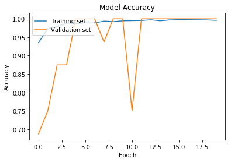

```python
# Accuracy
plt.plot(model_vgg16.history.history['acc'])
plt.plot(model_vgg16.history.history['val_acc'])
plt.title('Model Accuracy')
plt.ylabel('Accuracy')
plt.xlabel('Epoch')
plt.legend(['Training set', 'Validation set'], loc='upper left')
plt.show()
```

**Now set only the last dense layers to trainable**

```python
len(model_vgg16.trainable_weights)
```

```
26
```

```python
model_vgg16.layers[0].trainable = False
```

```python
len(model_vgg16.trainable_weights)
```

```
8
```

**Lowering the learning rate to really try and fine tune the final top layers**

```python
model_vgg16.compile(loss='binary_crossentropy', optimizer=Adam(lr=1e-6), metrics=['accuracy'])
```

```python
hist_model_vgg16 = model_vgg16.fit_generator(training_set,
                              steps_per_epoch = training_set.samples/training_set.batch_size,
                              epochs = 10,
                              validation_data = validation_set,
                              validation_steps = validation_set.samples/validation_set.batch_size, workers=8)
```

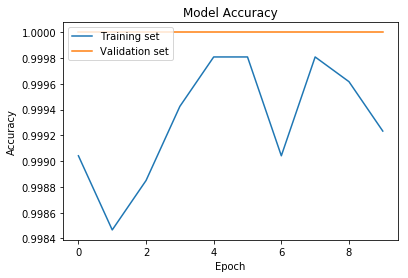

```python
# Accuracy
plt.plot(hist_model_vgg16.history['acc'])
plt.plot(hist_model_vgg16.history['val_acc'])
plt.title('Model Accuracy')
plt.ylabel('Accuracy')
plt.xlabel('Epoch')
plt.legend(['Training set', 'Validation set'], loc='upper left')
plt.show()
```

```python
score = model_vgg16.evaluate_generator(test_set, steps=test_set.samples/test_set.batch_size, verbose=1, workers=8)
print('Test loss:', score[0])
print('Test accuracy:', score[1]*100)
```

```
Test loss: 0.40921642813265907
Test accuracy: 93.10897435897436
```

```python
model_vgg16.save('C:/Computer Vision Project/model_vgg16.h5')
```

```python
model_vgg16 = load_model('C:/Computer Vision Project/model_vgg16.h5')
```

# DenseNet121

### Similar to VGG16 we want to train most of the top layers where the more specific features exist.

```python
from keras.applications import densenet
```

```python
conv_base_densenet = densenet.DenseNet121(include_top=False,
                                          weights="imagenet",
                                          input_shape=training_set.image_shape)
```

**Adding the top layers, and as we have only 2 classes (sick and not sick) we use the sigmoid function for the final fully connected layer**

```python
# Building the top layers
model_densenet = Sequential()
model_densenet.add(conv_base_densenet)
# Flatten the layer
model_densenet.add(Flatten())

model_densenet.add(Dense(units = 1024))
model_densenet.add(Dropout(0.3))
model_densenet.add(Activation('relu'))
model_densenet.add(Dense(units = 256))
model_densenet.add(Dropout(0.3))
model_densenet.add(Activation('relu'))
model_densenet.add(Dense(units = 32))

# Fully Connected Layers
model_densenet.add(Dense(activation = 'sigmoid', units = 1))
```

**Now to freeze the bottom layers**

```python
len(model_densenet.trainable_weights)
```

```
370
```

```python
for layer in conv_base_densenet.layers[:-285]:
    layer.trainable = False
```

```python
len(model_densenet.trainable_weights)
```

```
253
```

```python
model_densenet.summary()
```

```
_________________________________________________________________
Layer (type)                 Output Shape              Param #
=================================================================
densenet121 (Model)          (None, 7, 7, 1024)        7037504
_________________________________________________________________
flatten_4 (Flatten)          (None, 50176)             0
_________________________________________________________________
dense_13 (Dense)             (None, 1024)              51381248
_________________________________________________________________
dropout_7 (Dropout)          (None, 1024)              0
_________________________________________________________________
activation_195 (Activation)  (None, 1024)              0
_________________________________________________________________
dense_14 (Dense)             (None, 256)               262400
_________________________________________________________________
dropout_8 (Dropout)          (None, 256)               0
_________________________________________________________________
activation_196 (Activation)  (None, 256)               0
_________________________________________________________________
dense_15 (Dense)             (None, 32)                8224
_________________________________________________________________
dense_16 (Dense)             (None, 1)                 33
=================================================================
Total params: 58,689,409
Trainable params: 57,176,129
Non-trainable params: 1,513,280
_________________________________________________________________
```

**We use 'binary_crossentropy' as we have only 1 prediction class**

```python
model_densenet.compile(optimizer=Adam(lr=1e-5), loss='binary_crossentropy', metrics=['accuracy'])
```

```python
hist_model_densenet = model_densenet.fit_generator(training_set,
                              steps_per_epoch = training_set.samples/training_set.batch_size,
                              epochs = 20,
                              validation_data = validation_set,
                              validation_steps = validation_set.samples/validation_set.batch_size, workers=8)
```

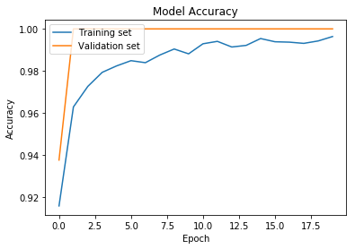

```python
# Accuracy
plt.plot(model_densenet.history.history['acc'])
plt.plot(model_densenet.history.history['val_acc'])
plt.title('Model Accuracy')
plt.ylabel('Accuracy')
plt.xlabel('Epoch')
plt.legend(['Training set', 'Validation set'], loc='upper left')
plt.show()
```

```python
score = model_densenet.evaluate_generator(test_set, steps=test_set.samples/test_set.batch_size, verbose=1, workers=8)
print('Test loss:', score[0])
print('Test accuracy:', score[1]*100)
```

```
Test loss: 0.48628992727026343
Test accuracy: 91.02564102564102
```

**Saving the model for later use while testing and iterating upon it**

```python
model_densenet.save('C:/Computer Vision Project/model_densenet121.h5')
```

```python
model_densenet = load_model('C:/Computer Vision Project/model_densenet121.h5')
```

# ResNet50

```python
from keras.applications import resnet50
```

```python
conv_base_resnet50 = resnet50.ResNet50(input_shape=training_set.image_shape,
                               include_top=False,
                               weights='imagenet')
```

conv_base_resnet50.summary()

```python
model_resnet50 = Sequential()
model_resnet50.add(conv_base_resnet50)
# Flatten the layer
model_resnet50.add(Flatten())

model_resnet50.add(Dense(units = 1024))
model_resnet50.add(Dropout(0.3))
model_resnet50.add(Activation('relu'))
model_resnet50.add(Dense(units = 256))
model_resnet50.add(Dropout(0.3))
model_resnet50.add(Activation('relu'))
model_resnet50.add(Dense(units = 32))

# Fully Connected Layers
model_resnet50.add(Dense(activation = 'sigmoid', units = 1))
```

```python
len(model_resnet50.trainable_weights)
```

```
220
```

```python
for layer in conv_base_resnet50.layers[:-32]:
    layer.trainable = False
```

```python
len(model_resnet50.trainable_weights)
```

```
48
```

```python
model_resnet50.compile(loss='binary_crossentropy', optimizer=Adam(lr=5e-5), metrics=['accuracy'])
```

```python
hist_resnet50_model = model_resnet50.fit_generator(training_set,
                              steps_per_epoch = training_set.samples/training_set.batch_size,
                              epochs = 20,
                              validation_data = validation_set,
                              validation_steps = validation_set.samples/validation_set.batch_size, workers=8)
```

```python
score = model_resnet50.evaluate_generator(test_set, steps=test_set.samples/test_set.batch_size, verbose=1, workers=8)
print('Test loss:', score[0])
print('Test accuracy:', score[1]*100)
```

```
Test loss: 0.4404217466429915
Test accuracy: 91.50641025641025
```

```python
len(model_resnet50.trainable_weights)
```

```
48
```

```python
conv_base_resnet50.trainable = False
```

```python
len(model_resnet50.trainable_weights)
```

```
8
```

```python
model_resnet50.compile(loss='binary_crossentropy', optimizer=Adam(lr=1e-5), metrics=['accuracy'])
```

```python
hist_resnet50_model = model_resnet50.fit_generator(training_set,
                              steps_per_epoch = training_set.samples/training_set.batch_size,
                              epochs = 20,
                              validation_data = validation_set,
                              validation_steps = validation_set.samples/validation_set.batch_size, workers=8)
```

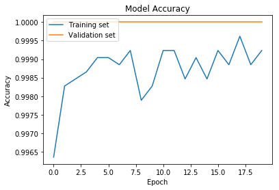

```python
# Accuracy
plt.plot(model_resnet50.history.history['acc'])
plt.plot(model_resnet50.history.history['val_acc'])
plt.title('Model Accuracy')
plt.ylabel('Accuracy')
plt.xlabel('Epoch')
plt.legend(['Training set', 'Validation set'], loc='upper left')
plt.show()
```

```python
score = model_resnet50.evaluate_generator(test_set, steps=test_set.samples/test_set.batch_size, verbose=1, workers=8)
print('Test loss:', score[0])
print('Test accuracy:', score[1]*100)
```

```
Test loss: 0.47595421427195106
Test accuracy: 93.91025641025641
```

```python
model_resnet50.save('C:/Computer Vision Project/model_resnet50.h5')
```

```python
model_resnet50 = load_model('C:/Computer Vision Project/model_resnet50.h5')
```

# NASNet

### After many tries and iterations NASnet did not benefit from freezing the layers so we train on the entire model.

```python
from keras.applications import nasnet
```

```python
conv_base_nasnet = nasnet.NASNetMobile(include_top=False,
                                      weights="imagenet",
                                      input_shape=training_set.image_shape)
```

```python
model_nasnet = Sequential()
model_nasnet.add(conv_base_nasnet)
# Flatten the layer
model_nasnet.add(Flatten())

model_nasnet.add(Dense(units = 1024))
model_nasnet.add(Dropout(0.3))
model_nasnet.add(Activation('relu'))
model_nasnet.add(Dense(units = 256))
model_nasnet.add(Dropout(0.3))
model_nasnet.add(Activation('relu'))
model_nasnet.add(Dense(units = 32))

# Fully Connected Layers
model_nasnet.add(Dense(activation = 'sigmoid', units = 1))
```

```python
model_nasnet.compile(loss='binary_crossentropy', optimizer=Adam(lr=1e-5), metrics=['accuracy'])
```

```python
hist_model_inceptionv3 = model_nasnet.fit_generator(training_set,
                              steps_per_epoch = training_set.samples/training_set.batch_size,
                              epochs = 20,
                              validation_data = validation_set,
                              validation_steps = validation_set.samples/validation_set.batch_size, workers=8)
```

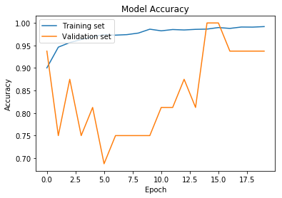

```python
# Accuracy
plt.plot(model_nasnet.history.history['acc'])
plt.plot(model_nasnet.history.history['val_acc'])
plt.title('Model Accuracy')
plt.ylabel('Accuracy')
plt.xlabel('Epoch')
plt.legend(['Training set', 'Validation set'], loc='upper left')
plt.show()
```

```python
score = model_nasnet.evaluate_generator(test_set, steps=test_set.samples/test_set.batch_size, verbose=1, workers=8)
print('Test loss:', score[0])
print('Test accuracy:', score[1]*100)
```

```
Test loss: 0.25712395951641387
Test accuracy: 92.46794871794873
```

```python
model_nasnet.save('C:/Computer Vision Project/model_nasnet.h5')
```

```python
model_nasnet = load_model('C:/Computer Vision Project/model_nasnet.h5')
```

# Inception v3

### Similar to NASnet, did not seem to benefit from freezing the bottom layers.

```python
from keras.applications import inception_v3
```

```python
conv_base_inceptionv3 = inception_v3.InceptionV3(include_top=False,
                                      weights="imagenet",
                                      input_shape=training_set.image_shape)
```

conv_base_inceptionv3.summary()

```python
model_inceptionv3 = Sequential()
model_inceptionv3.add(conv_base_inceptionv3)
# Flatten the layer
model_inceptionv3.add(Flatten())

model_inceptionv3.add(Dense(units = 1024))
model_inceptionv3.add(Dropout(0.3))
model_inceptionv3.add(Activation('relu'))
model_inceptionv3.add(Dense(units = 256))
model_inceptionv3.add(Dropout(0.3))
model_inceptionv3.add(Activation('relu'))
model_inceptionv3.add(Dense(units = 32))

# Fully Connected Layers
model_inceptionv3.add(Dense(activation = 'sigmoid', units = 1))
```

```python
model_inceptionv3.compile(loss='binary_crossentropy', optimizer=Adam(lr=1e-5), metrics=['accuracy'])
```

```python
hist_model_inceptionv3 = model_inceptionv3.fit_generator(training_set,
                              steps_per_epoch = training_set.samples/training_set.batch_size,
                              epochs = 20,
                              validation_data = validation_set,
                              validation_steps = validation_set.samples/validation_set.batch_size, workers=8)
```

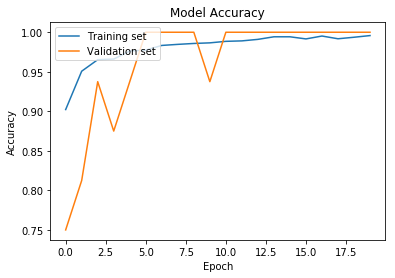

```python
# Accuracy
plt.plot(model_inceptionv3.history.history['acc'])
plt.plot(model_inceptionv3.history.history['val_acc'])
plt.title('Model Accuracy')
plt.ylabel('Accuracy')
plt.xlabel('Epoch')
plt.legend(['Training set', 'Validation set'], loc='upper left')
plt.show()
```

```python
score = model_inceptionv3.evaluate_generator(test_set, steps=test_set.samples/test_set.batch_size, verbose=1, workers=8)
print('Test loss:', score[0])
print('Test accuracy:', score[1]*100)
```

```
Test loss: 0.3147201066215833
Test accuracy: 90.38461538461539
```

```python
model_inceptionv3.save('C:/Computer Vision Project/model_inceptionv3.h5')
```

```python
model_inceptionv3 = load_model('C:/Computer Vision Project/model_inceptionv3.h5')
```

# Ensemble

### Now to ensemble all of our models' predictions together using Average

```python
model_vgg16 = load_model('C:/Computer Vision Project/model_vgg16.h5')
model_densenet = load_model('C:/Computer Vision Project/model_densenet121.h5')
model_nasnet = load_model('C:/Computer Vision Project/model_nasnet.h5')
model_resnet50 = load_model('C:/Computer Vision Project/model_resnet50.h5')
model_inceptionv3 = load_model('C:/Computer Vision Project/model_inceptionv3.h5')
```

```python
from keras.models import Model
from keras.layers import Input
from keras.layers import Average

models = [model_densenet, model_vgg16, model_resnet50, model_nasnet, model_inceptionv3]
```

```python
def ensemble_models(models, model_input):
    # collect outputs of models in a list
    y_models=[model(model_input) for model in models]
    # averaging outputs
    #y_avg=Average()(y_models)
    y_avg=Average()(y_models)
    # build model from same input and avg output
    model_ens = Model(inputs=model_input, outputs=y_avg, name='ensemble')
    return model_ens
```

```python
model_input = Input(shape=models[0].input_shape[1:])
model_ens = ensemble_models(models, model_input)
model_ens.summary()
```

```
__________________________________________________________________________________________________
Layer (type)                    Output Shape         Param #     Connected to
==================================================================================================
input_1 (InputLayer)            (None, 224, 224, 3)  0
__________________________________________________________________________________________________
sequential_2 (Sequential)       (None, 1)            58689409    input_1[0][0]
__________________________________________________________________________________________________
sequential_1 (Sequential)       (None, 1)            40676481    input_1[0][0]
__________________________________________________________________________________________________
sequential_4 (Sequential)       (None, 1)            126619841   input_1[0][0]
__________________________________________________________________________________________________
sequential_3 (Sequential)       (None, 1)            57527253    input_1[0][0]
__________________________________________________________________________________________________
sequential_5 (Sequential)       (None, 1)            74503265    input_1[0][0]
__________________________________________________________________________________________________
average_1 (Average)             (None, 1)            0           sequential_2[1][0]
                                                                 sequential_1[1][0]
                                                                 sequential_4[1][0]
                                                                 sequential_3[1][0]
                                                                 sequential_5[1][0]
==================================================================================================
Total params: 358,016,249
Trainable params: 347,559,927
Non-trainable params: 10,456,322
__________________________________________________________________________________________________
```

```python
model_ens.compile(loss='binary_crossentropy', optimizer=Adam(lr=1e-5), metrics=['accuracy'])
```

```python
score = model_ens.evaluate_generator(test_set, steps=test_set.samples/test_set.batch_size, verbose=1, workers=8)
print('Test loss:', score[0])
print('Test accuracy:', score[1]*100)
```

```
Test loss: 0.15669572838128376
Test accuracy: 94.55128205128204
```

```python
batch = next(test_set)
```

```python
preds = model_ens.predict_on_batch(batch[0])
```

```python
preds1 = np.around(preds)
```

```python
test_set.class_indices
```

```
{'NORMAL': 0, 'PNEUMONIA': 1}
```

```python
labels_dict = {0:'Normal', 1:'Pneumonia'}
```

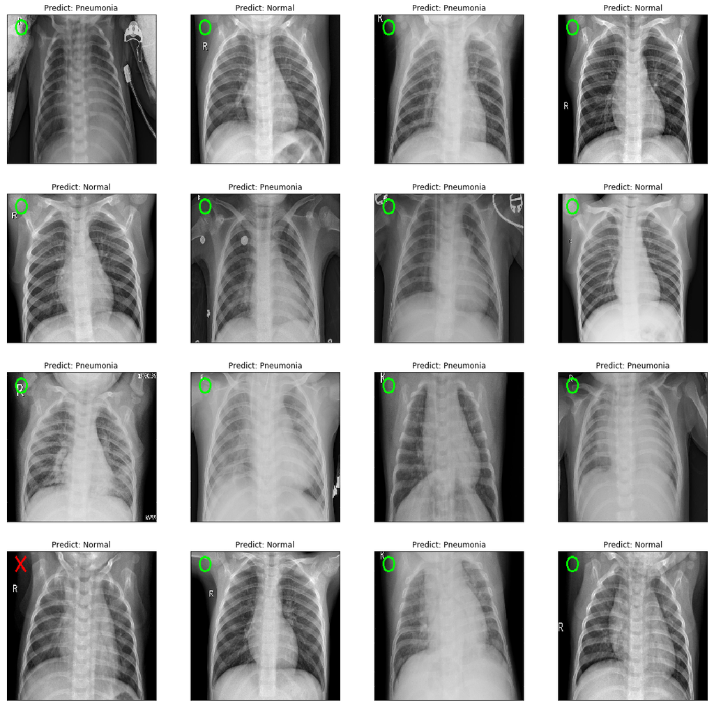

```python
font = cv2.FONT_HERSHEY_SIMPLEX
plt.figure(figsize=[20,20])

for index in range(16):
    plt.subplot(4,4,index+1)
    img = batch[0][index].copy()
    if preds1[index] == batch[1][index]:
        cv2.putText(img,'O',(10,30), font, 1,(0,255,0),2,cv2.LINE_AA)
    else:
        cv2.putText(img,'X',(10,30), font, 1,(255,0,0),2,cv2.LINE_AA)
    plt.imshow(np.clip(img, 0, 1).astype(np.float))
    plt.title("Predict: " + str(labels_dict[int(preds1[index])]))
    plt.tick_params(axis='both', which='both', bottom=False, left=False, labelbottom=False, labelleft=False)
```

```python
# Given unshuffled test set

def get_recall_precision(model, test_set):
    preds = model.predict_generator(test_set, workers=8)
    y_pred = np.around(preds)
    y_true = test_set.classes

    tn, fp, fn, tp = 0, 0, 0, 0

    for index in range(len(y_true)):
        if y_pred[index] == 1 and y_true[index] == 1:
            tp += 1
        if y_pred[index] == 0 and y_true[index] == 0:
            tn += 1
        if y_pred[index] == 0 and y_true[index] == 1:
            fn += 1
        if y_pred[index] == 1 and y_true[index] == 0:
            fp += 1

    recall = tp/(tp+fn)
    precision = tp/(tp+fp)

    return recall, precision
```

```python
pred_test_datagen = ImageDataGenerator(rescale = 1./255)  #Image normalization.

pred_test_set = pred_test_datagen.flow_from_directory(test_folder,
                                            target_size = input_shape,
                                            batch_size = batch_size,
                                            class_mode = 'binary',
                                            shuffle = False)
```

```
Found 624 images belonging to 2 classes.
```

### Recall and Precision for the **DenseNet** Model

```python
recall, precision = get_recall_precision(model_densenet, pred_test_set)
print("Recall of the model is: {:.4f}".format(recall))
print("Precision of the model is: {:.4f}".format(precision*100))
```

```
Recall of the model is: 0.9103
Precision of the model is: 94.4149
```

### Recall and Precision for the **VGG16** Model

```python
recall, precision = get_recall_precision(model_vgg16, pred_test_set)
print("Recall of the model is: {:.4f}".format(recall))
print("Precision of the model is: {:.4f}".format(precision*100))
```

```
Recall of the model is: 0.9692
Precision of the model is: 92.4205
```

### Recall and Precision for the **Inceptionv3** Model

```python
recall, precision = get_recall_precision(model_inceptionv3, pred_test_set)
print("Recall of the model is: {:.4f}".format(recall))
print("Precision of the model is: {:.4f}".format(precision*100))
```

```
Recall of the model is: 0.8872
Precision of the model is: 95.5801
```

### Recall and Precision for the **NASnet** Model

```python
recall, precision = get_recall_precision(model_nasnet, pred_test_set)
print("Recall of the model is: {:.4f}".format(recall))
print("Precision of the model is: {:.4f}".format(precision*100))
```

```
Recall of the model is: 0.9410
Precision of the model is: 93.8619
```

### Recall and Precision for the **ResNet50** Model

```python
recall, precision = get_recall_precision(model_resnet50, pred_test_set)
print("Recall of the model is: {:.4f}".format(recall))
print("Precision of the model is: {:.4f}".format(precision*100))
```

```
Recall of the model is: 0.9667
Precision of the model is: 93.7811
```

### Recall and Precision for the **Ensemble** Model

```python
recall, precision = get_recall_precision(model_ens, pred_test_set)
print("Recall of the model is: {:.4f}".format(recall))
print("Precision of the model is: {:.4f}".format(precision*100))
```

```
Recall of the model is: 0.9692
Precision of the model is: 94.5000
```

*The ensemble yielded us both a high precision and recall, not a bad result!*

## Models' Scores side by side

```python
score = model_densenet.evaluate_generator(test_set, steps=test_set.samples/test_set.batch_size, verbose=1, workers=8)
print('Test loss:', score[0])
print('Test accuracy:', score[1]*100)
```

```
Test loss: 0.4862899357297768
Test accuracy: 91.02564102564102
```

```python
score = model_vgg16.evaluate_generator(test_set, steps=test_set.samples/test_set.batch_size, verbose=1, workers=8)
print('Test loss:', score[0])
print('Test accuracy:', score[1]*100)
```

```
Test loss: 0.4092164453848874
Test accuracy: 93.10897435897436
```

```python
score = model_inceptionv3.evaluate_generator(test_set, steps=test_set.samples/test_set.batch_size, verbose=1, workers=8)
print('Test loss:', score[0])
print('Test accuracy:', score[1]*100)
```

```
Test loss: 0.31472009231742376
Test accuracy: 90.38461538461539
```

```python
score = model_resnet50.evaluate_generator(test_set, steps=test_set.samples/test_set.batch_size, verbose=1, workers=8)
print('Test loss:', score[0])
print('Test accuracy:', score[1]*100)
```

```
Test loss: 0.4759542180825211
Test accuracy: 93.91025641025641
```

```python
score = model_nasnet.evaluate_generator(test_set, steps=test_set.samples/test_set.batch_size, verbose=1, workers=8)
print('Test loss:', score[0])
print('Test accuracy:', score[1]*100)
```

```
Test loss: 0.25712396415810174
Test accuracy: 92.46794871794873
```

```python
score = model_ens.evaluate_generator(test_set, steps=test_set.samples/test_set.batch_size, verbose=1, workers=8)
print('Test loss:', score[0])
print('Test accuracy:', score[1]*100)
```

```
Test loss: 0.15669572974244753
Test accuracy: 94.55128205128204
```

Overall highest accuracy is with our ensemble model with 94.5% accuracy.  
I would call that a success!